# analysis_2-10

Kevin Ros

2/6/2020

Collaboration: I wasn’t sure where to start, and Henrik pointed me in the direction of last year’s multiple linear regression slides: https://github.com/monika76five/Undergrad-Bayesian-Statistics/blob/master/Lectures/BayesianLinearRegression/F19MATH347_Regression_R.pdf which I implemented, as it wasn’t too clear how to do hierarchical modeling with categorical variables (but I think fastDummies can be used). Additionally, Henrik and I discussed the simulation portion, namely how one needs to pass a data frame of each variable, and not just income.

```r
library(ggplot2)
library(coda)
library(runjags)
library(fastDummies)
data = data.frame(read.csv("../datasets/CEdata.csv",header=TRUE))
```

````r
# EXAMPLE FROM CLASS

# modelString <-"
# model {
# ## sampling
# for (i in 1:N){
# y[i] ~ dnorm(beta0 + beta1*x[i], invsigma2)
# }
#
# ## priors
# beta0 ~ dnorm(mu0, g0)
# beta1 ~ dnorm(mu1, g1)
# invsigma2 ~ dgamma(a,b)
# sigma <- sqrt(pow(invsigma2,-1))
# }
# "
#
# y <- as.vector(log(data$TotalIncomeLastYear))
# x <- as.vector(log(data$TotalExpLastQ))
# N <-length(y)
# the_data <- list("y" = y, "x" = x, "N" = N,
#                  "mu0" = 0, "g0" = 0.0001,
#                  "mu1" = 0, "g1" = 0.0001,
#                  "a" = 1, "b" = 1)
#
# initsfunction <- function(chain){
#   .RNG.seed <- c(1,2)[chain]
#   .RNG.name <- c("base::SuperDuper",
#                  "base::Wichmann-Hill")[chain]
#   return(list(.RNG.seed=.RNG.seed,
#               .RNG.name-.RNG.name))
# }
# ```
#
# ```{r}
# posterior <- run.jags(modelString,
#                       n.chains = 1,
#                       data = the_data,
#                       monitor = c("beta0","beta1","sigma"),
#                       adapt = 1000,
#                       burnin = 5000,
#                       sample = 5000,
#                       thin = 50)
# plot(posterior, vars = "beta0")
````

The original slides has scale(), but I removed it to better interpret the results.

```r
data$log_TotalExpSTD <- log(data$Expenditure)
data$log_TotalIncomeSTD <- log(data$Income)
```

Create the binary columns and rows for each categorical variable:

```r
data$Rural = fastDummies::dummy_cols(data$UrbanRural)[,names(fastDummies::dummy_cols(data$UrbanRural))== ".data_2"]
data$Race_Black = fastDummies::dummy_cols(data$Race)[,names(fastDummies::dummy_cols(data$Race)) == ".data_2"]
data$Race_NA = fastDummies::dummy_cols(data$Race)[,names(fastDummies::dummy_cols(data$Race)) == ".data_3"]
data$Race_Asian = fastDummies::dummy_cols(data$Race)[,names(fastDummies::dummy_cols(data$Race)) == ".data_4"]
data$Race_PI = fastDummies::dummy_cols(data$Race)[,names(fastDummies::dummy_cols(data$Race)) == ".data_5"]
data$Race_M = fastDummies::dummy_cols(data$Race)[,names(fastDummies::dummy_cols(data$Race)) == ".data_6"]
```

Same parameters from slides:

```r
modelString <-"
model {
## sampling
for (i in 1:N){
y[i] ~ dnorm(beta0 + beta1*x_income[i] + beta2*x_rural[i] +
beta3*x_race_B[i] + beta4*x_race_N[i] +
beta5*x_race_A[i] + beta6*x_race_P[i] +
beta7*x_race_M[i], invsigma2)
}
## priors
beta0 ~ dnorm(mu0, g0)
beta1 ~ dnorm(mu1, g1)
beta2 ~ dnorm(mu2, g2)
beta3 ~ dnorm(mu3, g3)
beta4 ~ dnorm(mu4, g4)
beta5 ~ dnorm(mu5, g5)
beta6 ~ dnorm(mu6, g6)
beta7 ~ dnorm(mu7, g7)
invsigma2 ~ dgamma(a, b)
sigma <- sqrt(pow(invsigma2, -1))
}
"
```

```r
y = as.vector(data$log_TotalExpSTD)
x_income = as.vector(data$log_TotalIncomeSTD)
x_rural = as.vector(data$Rural)
x_race_B = as.vector(data$Race_Black)
x_race_N = as.vector(data$Race_NA)
x_race_A = as.vector(data$Race_Asian)
x_race_P = as.vector(data$Race_PI)
x_race_M = as.vector(data$Race_M)
N = length(y)
```

Same parameter values from slides:

```r
the_data <- list("y" = y, "x_income" = x_income,
                 "x_rural" = x_rural, "x_race_B" = x_race_B,
                 "x_race_N" = x_race_N, "x_race_A" = x_race_A,
                 "x_race_P" = x_race_P, "x_race_M" = x_race_M,
                 "N" = N,
                 "mu0" = 0, "g0" = 1, "mu1" = 0, "g1" = 1,
                 "mu2" = 0, "g2" = 1, "mu3" = 0, "g3" = 1,
                 "mu4" = 0, "g4" = 1, "mu5" = 0, "g5" = 1,
                 "mu6" = 0, "g6" = 1, "mu7" = 0, "g7" = 1,
                 "a" = 1, "b" = 1)
```

```r
initsfunction <- function(chain){
  .RNG.seed <- c(1,2)[chain]
  .RNG.name <- c("base::Super-Duper",
                 "base::Wichmann-Hill")[chain]
  return(list(.RNG.seed=.RNG.seed,
              .RNG.name=.RNG.name))
}
```

Thinning of 50 is needed, otherwise beta0 and beta1 have very high lag

```r
posterior_MLR <- run.jags(modelString,
                      n.chains = 1,
                      data = the_data,
                      monitor = c("beta0", "beta1", "beta2",
                                  "beta3", "beta4", "beta5",
                                  "beta6", "beta7", "sigma"),
                      adapt = 1000,
                      burnin = 5000,
                      sample = 5000,
                      thin = 50,
                      inits = initsfunction)
```

```
## Compiling rjags model...
## Calling the simulation using the rjags method...
## Note: the model did not require adaptation
## Burning in the model for 5000 iterations...
## Running the model for 250000 iterations...
## Simulation complete
## Calculating summary statistics...
```

```
## Finished running the simulation
```

```r
summary(posterior_MLR)
```

```
##          Lower95       Median     Upper95         Mean         SD Mode
## beta0  3.8401288  4.265856654  4.68625457  4.270064662 0.21777079   NA
## beta1  0.3882419  0.428382748  0.46702186  0.428186927 0.02024773   NA
## beta2 -0.4324816 -0.227295748 -0.02303789 -0.226517253 0.10523080   NA
## beta3 -0.3306556 -0.190482478 -0.04140575 -0.191212993 0.07415444   NA
## beta4 -0.5206527  0.004840372  0.51719407  0.004623109 0.26616225   NA
## beta5 -0.0510838  0.162814921  0.40645797  0.162083182 0.11830143   NA
## beta6 -0.4595443  0.083013003  0.68580148  0.082703016 0.28996472   NA
## beta7 -0.2892273  0.040916578  0.39024470  0.042723529 0.17484430   NA
## sigma  0.6904107  0.721247329  0.75457051  0.721355983 0.01634697   NA
##              MCerr MC%ofSD SSeff        AC.500 psrf
## beta0 0.0058531144     2.7  1384  8.671215e-03   NA
## beta1 0.0005445194     2.7  1383  1.118156e-02   NA
## beta2 0.0014881883     1.4  5000  3.940920e-03   NA
## beta3 0.0010321668     1.4  5161  1.701377e-03   NA
## beta4 0.0037641027     1.4  5000  6.253260e-03   NA
## beta5 0.0017356791     1.5  4646  3.048365e-02   NA
## beta6 0.0041007204     1.4  5000  9.247818e-03   NA
## beta7 0.0024726717     1.4  5000  1.516543e-02   NA
## sigma 0.0002311811     1.4  5000 -1.238722e-05   NA
```

```
## Generating plots...
```

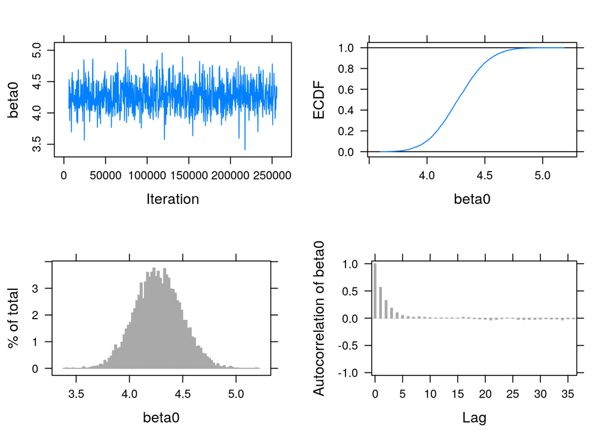

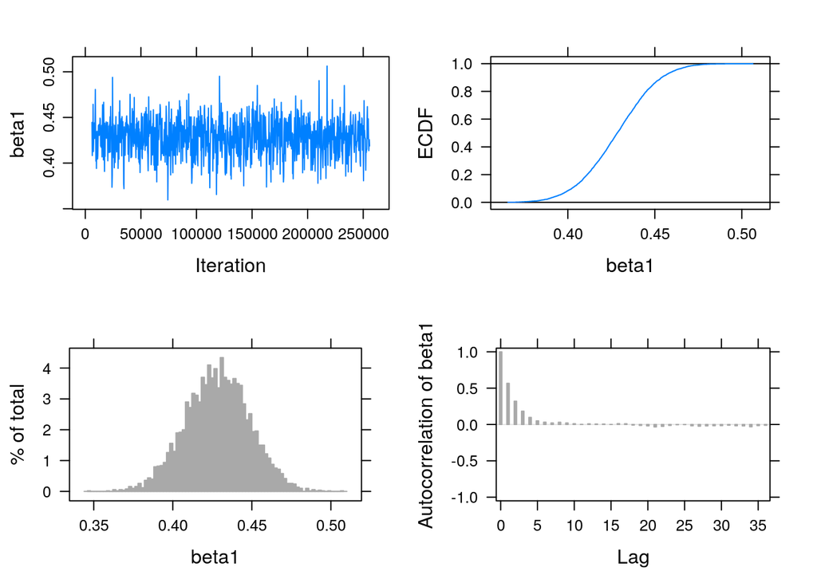

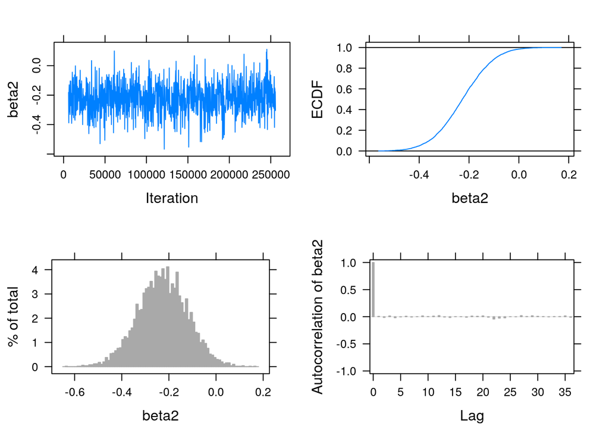

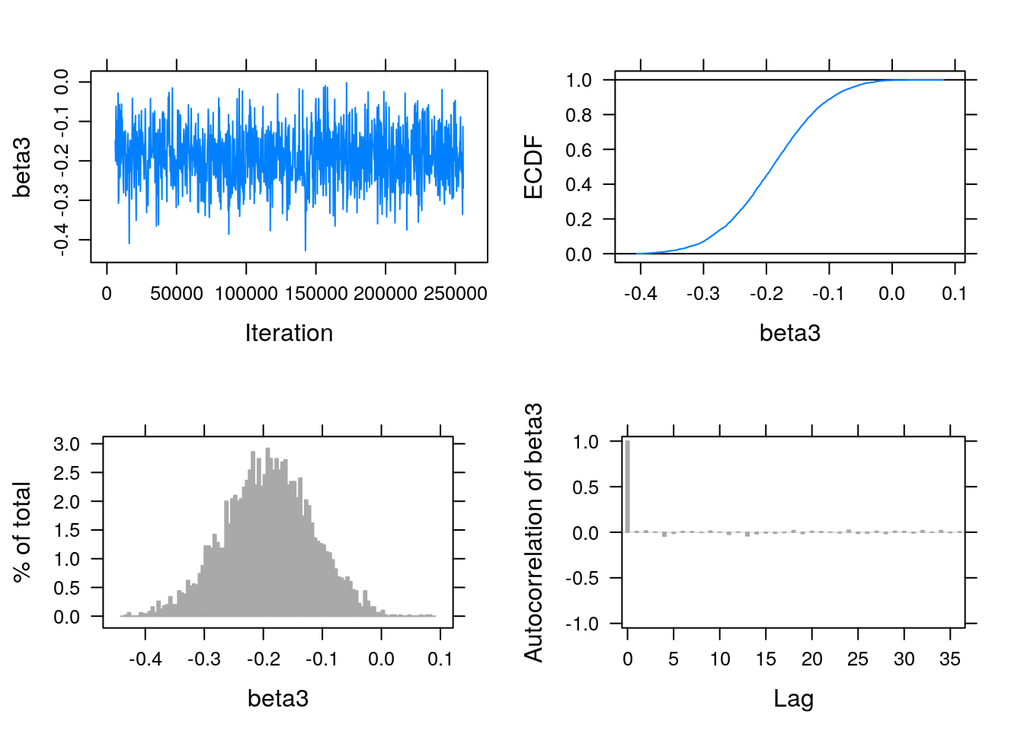

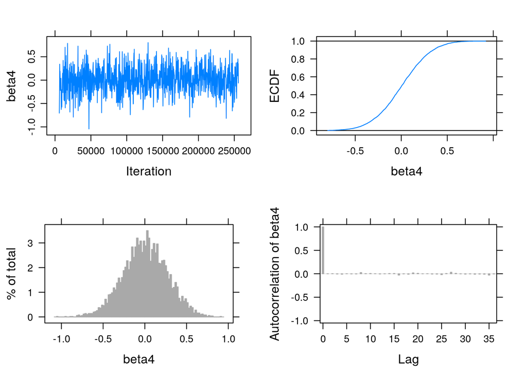

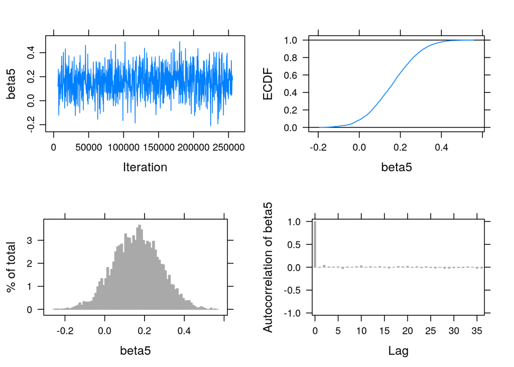

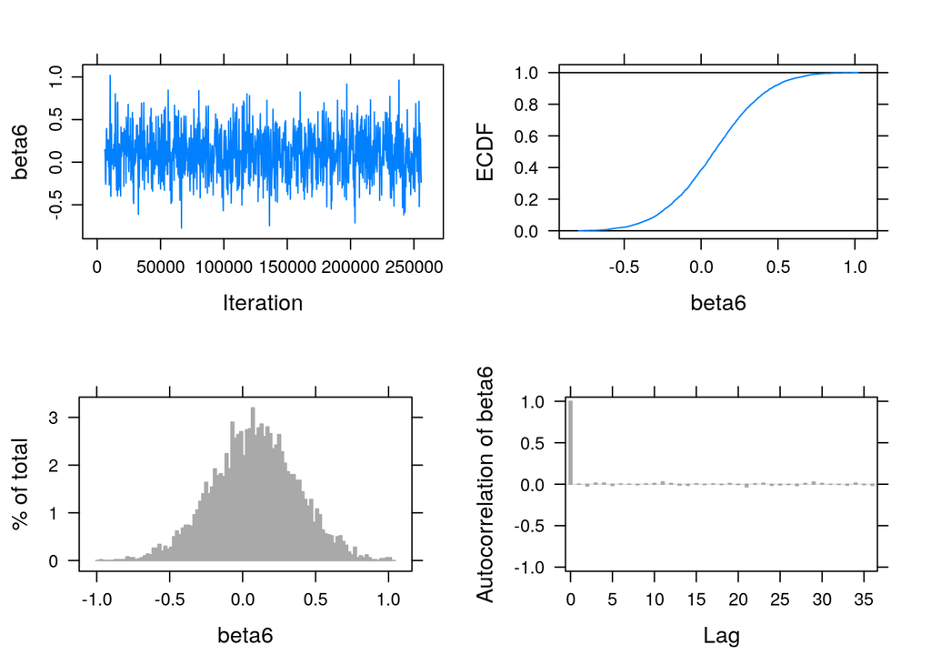

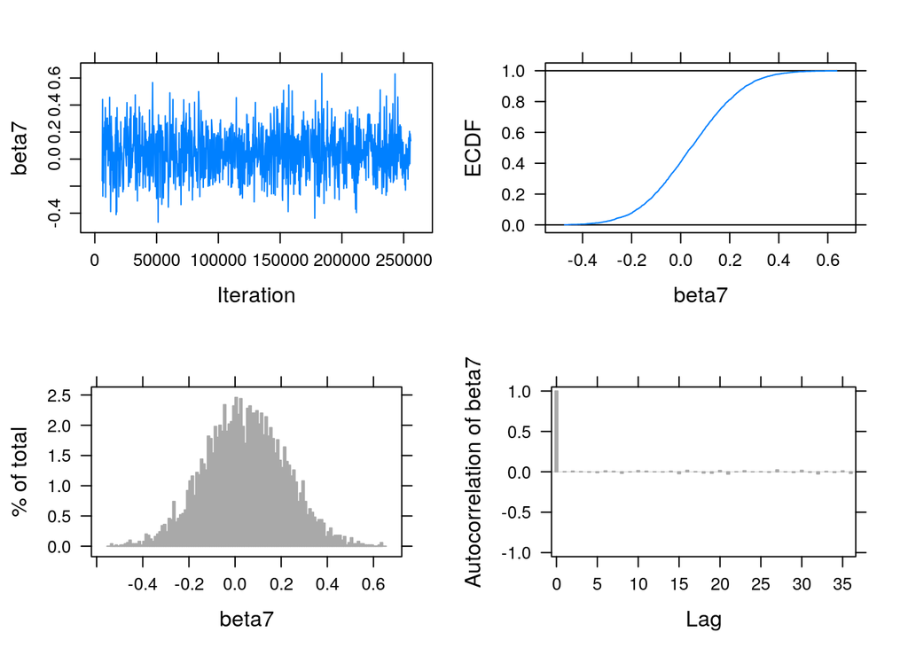

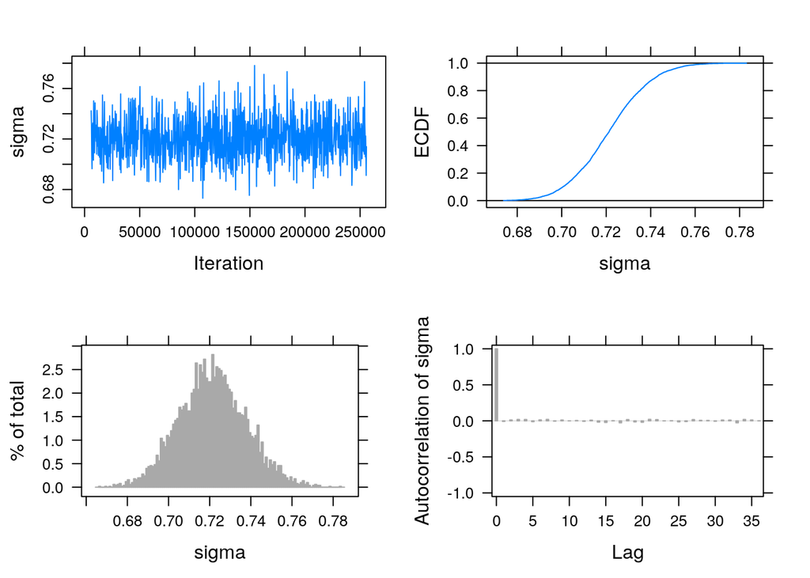

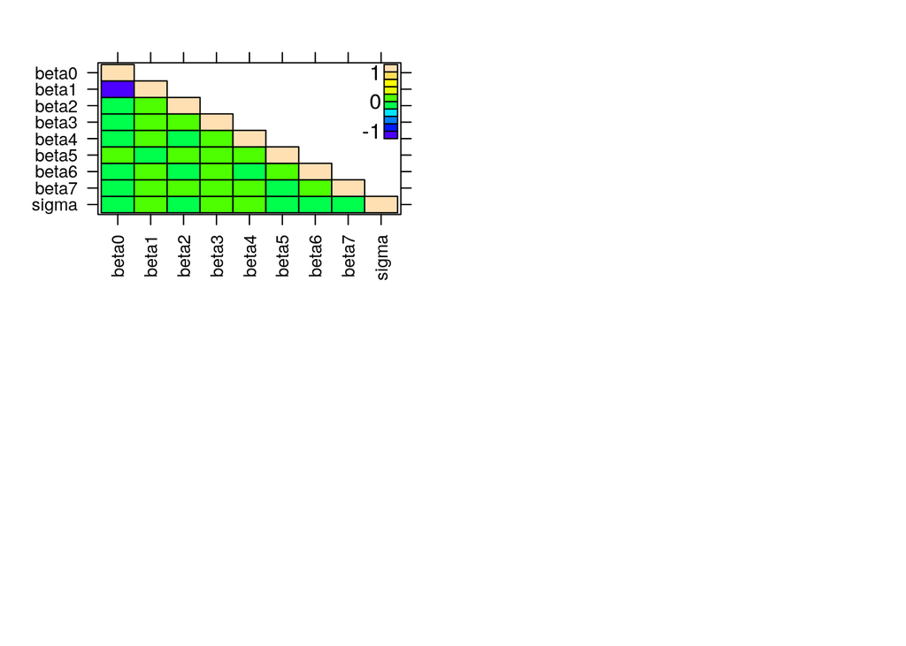

```r
plot(posterior_MLR)
```